# Import des librairies

### Score ROC AUC

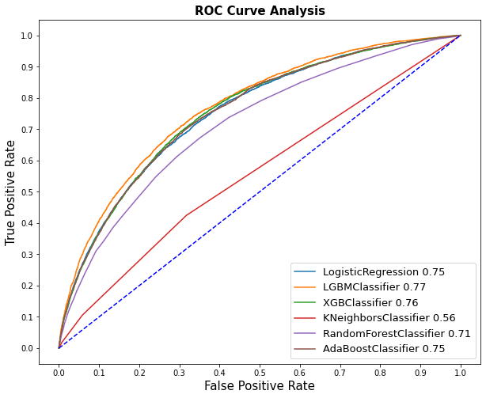

```python
fig = plt.figure(figsize=(10,8))

for i in df_models.index:
    plt.plot(df_models.loc[i]['fpr'],
             df_models.loc[i]['tpr'],
             label=df_models.loc[i]['model']+ f" {df_models.loc[i]['roc auc score']:.2f}"
             )

plt.plot([0,1], [0,1], color='blue', linestyle='--')

plt.xticks(np.arange(0.0, 1.1, step=0.1))
plt.xlabel("False Positive Rate", fontsize=15)

plt.yticks(np.arange(0.0, 1.1, step=0.1))
plt.ylabel("True Positive Rate", fontsize=15)

plt.title('ROC Curve Analysis', fontweight='bold', fontsize=15)
plt.legend(prop={'size':13}, loc='lower right')

plt.show()
```

## Resampling

### Over Sampling

SMOTE to create synthetic samples similar to the actual data to equalize our classes.

```python
over_sm = SMOTE(sampling_strategy=0.85)
X_train_over_sm, y_train_over_sm = over_sm.fit_resample(X_train, y_train)
y_train_over_sm.value_counts(normalize=True)
```

```
0.0    0.540543
1.0    0.459457
Name: TARGET, dtype: float64
```

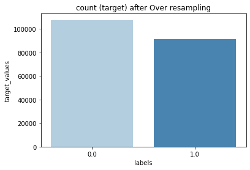

```python
target = y_train_over_sm.value_counts()
df = pd.DataFrame({'labels': target.index,
                   'target_values': target.values
                  })
plt.title('count (target) after Over resampling')
sns.barplot(x = 'labels', y="target_values", data=df, palette='Blues')
plt.show()
```

#### Dummy Classifier

Updating the Dummy

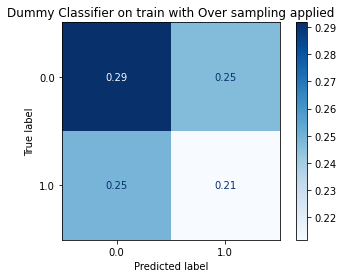

```python
#updating Dummy Classifier with SMOTE’d data
clf_over_sm = DummyClassifier(strategy='stratified')
clf_over_sm.fit(X_train_over_sm, y_train_over_sm)
y_pred = clf_over_sm.predict(X_train_over_sm)

cm = plot_confusion_matrix(estimator=clf_over_sm, X=X_train_over_sm, y_true=y_pred,
                      normalize='all', cmap='Blues')
plt.grid(False)

cm.ax_.set_title("Dummy Classifier on train with Over sampling applied")
```

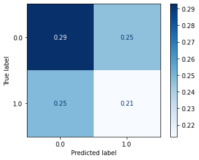

```python
#updating Dummy Classifier with SMOTE’d data
clf_over_sm = DummyClassifier(strategy='stratified')
clf_over_sm.fit(X_train_over_sm, y_train_over_sm)
y_pred = clf_over_sm.predict(X_test)
plot_confusion_matrix(estimator=clf_over_sm, X=X_test, y_true=y_pred,
                      normalize='all', cmap='Blues')
plt.grid(False)

cm.ax_.set_title("Dummy Classifier on test with Over sampling applied")
```

### Under Sampling

```python
from imblearn.under_sampling import RandomUnderSampler

under_sm = RandomUnderSampler(sampling_strategy=0.75)
```

```python
X_train_under_sm, y_train_under_sm = under_sm.fit_resample(X_train, y_train)
y_train_under_sm.value_counts(normalize=True)
```

```
0.0    0.571422
1.0    0.428578
Name: TARGET, dtype: float64
```

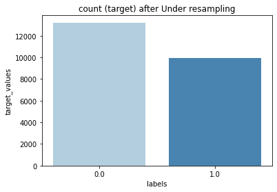

```python
target = y_train_under_sm.value_counts()
df = pd.DataFrame({'labels': target.index,
                   'target_values': target.values
                  })
plt.title('count (target) after Under resampling')
sns.barplot(x = 'labels', y="target_values", data=df, palette='Blues')
plt.show()
```

#### Dummy Classifier

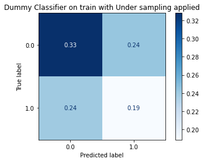

```python
#updating Dummy Classifier with SMOTE’d data
clf_under_sm = DummyClassifier(strategy='stratified')
clf_under_sm.fit(X_train_under_sm, y_train_under_sm)
y_pred = clf_under_sm.predict(X_train_under_sm)
cm = plot_confusion_matrix(estimator=clf_under_sm, X=X_train_under_sm, y_true=y_pred,
                      normalize='all', cmap='Blues')
plt.grid(False)

cm.ax_.set_title("Dummy Classifier on train with Under sampling applied")
```

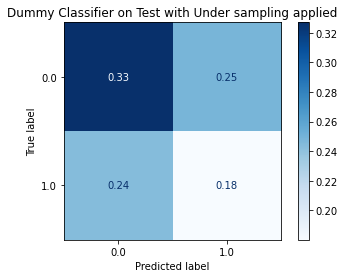

```python
#updating Dummy Classifier with SMOTE’d data
clf_under_sm = DummyClassifier(strategy='stratified')
clf_under_sm.fit(X_train_under_sm, y_train_under_sm)
y_pred = clf_under_sm.predict(X_test)
cm = plot_confusion_matrix(estimator=clf_under_sm, X=X_test, y_true=y_pred,
                      normalize='all', cmap='Blues')
plt.grid(False)

cm.ax_.set_title("Dummy Classifier on Test with Under sampling applied")
```

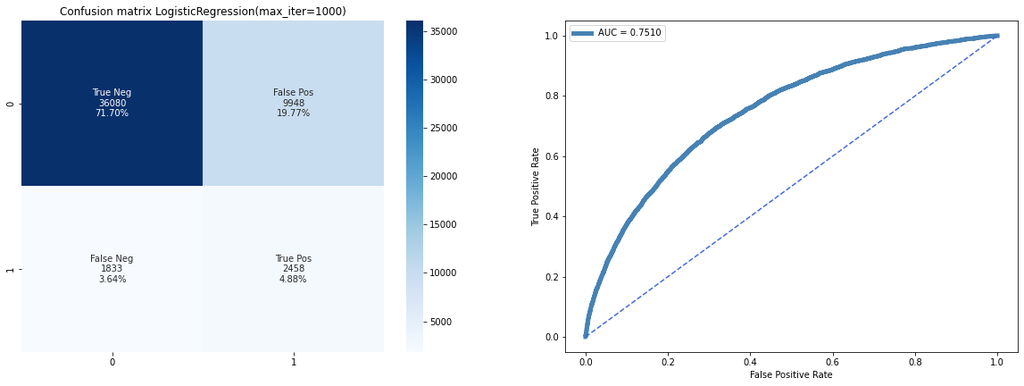

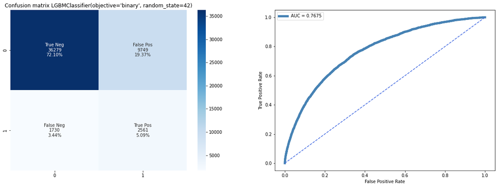

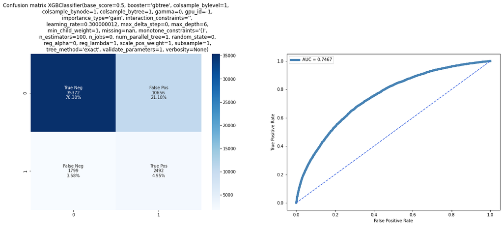

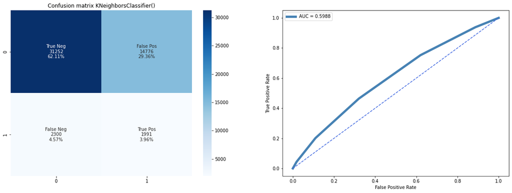

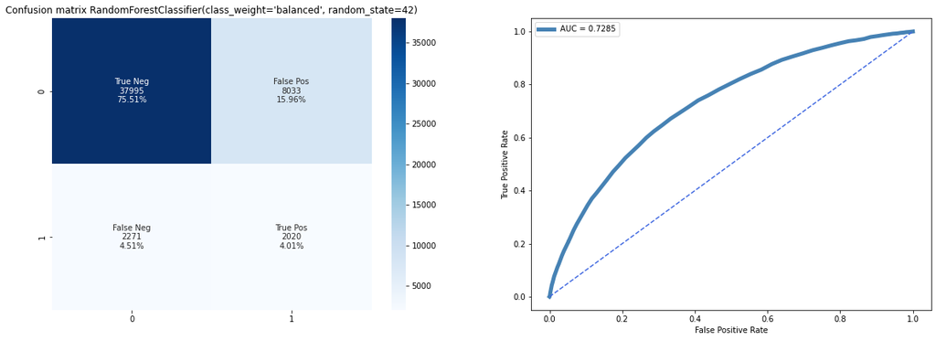

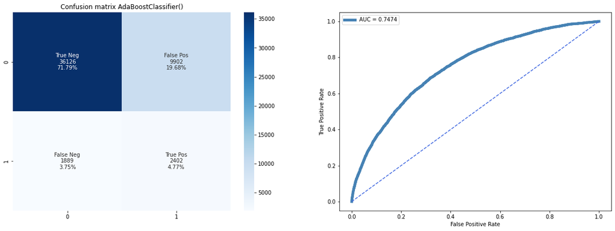

```python
df_model_over = pd.DataFrame(columns=['model', 'run_time', 'Score test', 'Score train', 'accuracy', 'precision', 'recall', 'f1_score', 'roc auc score', 'fpr', 'tpr','fbeta'])

for key in classifiers:

    start_time = time.time()
    classifier_over = classifiers[key]
    model_over = classifier_over.fit(X_train_under_sm, y_train_under_sm)

    y_pred_over = model_over.predict(X_test)
    y_pred_proba_over = model_over.predict_proba(X_test)[:,1]

    fig = plt.figure(figsize=(20,15))

    plt.subplot(221)
    # Compute confusion matrix
    cnf_matrix = confusion_matrix(y_test, y_pred_over)
    group_names = ['True Neg', 'False Pos', 'False Neg', 'True Pos']
    group_counts = ["{0:0.0f}".format(value) for value in cnf_matrix.flatten()]
    group_percentages = ["{0:.2%}".format(value) for value in cnf_matrix.flatten()/np.sum(cnf_matrix)]

    labels = [f"{v1}\n{v2}\n{v3}" for v1, v2, v3 in zip(group_names,group_counts,group_percentages)]
    labels = np.asarray(labels).reshape(2,2)
    sns.heatmap(cnf_matrix, annot=labels, fmt="", cmap='Blues')

    plt.title(f'Confusion matrix {classifier_over}')


    plt.subplot(222)
    fpr,tpr,_ = roc_curve(y_test, y_pred_proba_over)
    plt.plot(fpr, tpr, color='steelblue', linewidth=5, label='AUC = %0.4f' %roc_auc_score(y_test, y_pred_proba_over))
    plt.plot([0, 1], [0, 1], color='royalblue', linestyle='--')
    plt.xlabel('False Positive Rate')
    plt.ylabel('True Positive Rate')
    plt.legend()

    plt.show()

    row = {'model': key,
           'run_time': format(round((time.time() - start_time)/60,2)),
           'Score test': model_over.score(X_test,y_test),
           'Score train': model_over.score(X_train_under_sm,y_train_under_sm),
           'accuracy': accuracy_score(y_test, y_pred_over),
           'precision': precision_score(y_test, y_pred_over, average='binary'),
           'recall': recall_score(y_test, y_pred_over, average='binary'),
           'f1_score': f1_score(y_test, y_pred_over, average='binary'),
           'roc auc score': roc_auc_score(y_test, y_pred_proba_over),
           'fpr':fpr,
           'tpr':tpr,
           'fbeta': fbeta_score(y_test,model_over.predict(X_test),beta=10)
    }

    df_model_over = df_model_over.append(row, ignore_index=True)
```

```python
df_model_over
```

|  | model | run_time | Score test | Score train | accuracy | precision | recall | f1_score | roc auc score | fpr | tpr | fbeta |
| --- | --- | --- | --- | --- | --- | --- | --- | --- | --- | --- | --- | --- |
| 0 | LogisticRegression | 0.27 | 0.765874 | 0.704888 | 0.765874 | 0.198130 | 0.572827 | 0.294424 | 0.750998 | [0.0, 2.172590597027896e-05, 4.345181194055792... | [0.0, 0.0, 0.0, 0.00046609182008855747, 0.0004... | 0.562298 |
| 1 | LGBMClassifier | 0.18 | 0.771875 | 0.819856 | 0.771875 | 0.208042 | 0.596831 | 0.308536 | 0.767460 | [0.0, 0.0, 0.0, 2.172590597027896e-05, 2.17259... | [0.0, 0.00023304591004427873, 0.00046609182008... | 0.585988 |
| 2 | XGBClassifier | 0.78 | 0.752479 | 0.921511 | 0.752479 | 0.189535 | 0.580750 | 0.285796 | 0.746687 | [0.0, 2.172590597027896e-05, 2.172590597027896... | [0.0, 0.0, 0.0006991377301328362, 0.0006991377... | 0.569120 |
| 3 | KNeighborsClassifier | 1.07 | 0.660645 | 0.742577 | 0.660645 | 0.118745 | 0.463994 | 0.189097 | 0.598794 | [0.0, 0.018314938732945162, 0.1098461805857304... | [0.0, 0.0438126310883244, 0.20135166627825682,... | 0.451011 |
| 4 | RandomForestClassifier | 0.41 | 0.795226 | 1.000000 | 0.795226 | 0.200935 | 0.470753 | 0.281651 | 0.728458 | [0.0, 2.172590597027896e-05, 8.690362388111584... | [0.0, 0.0, 0.0, 0.00023304591004427873, 0.0004... | 0.464576 |
| 5 | AdaBoostClassifier | 0.62 | 0.765675 | 0.705407 | 0.765675 | 0.195221 | 0.559776 | 0.289485 | 0.747432 | [0.0, 0.0, 0.0, 4.345181194055792e-05, 4.34518... | [0.0, 0.00023304591004427873, 0.00046609182008... | 0.549614 |

### Score ROC AUC

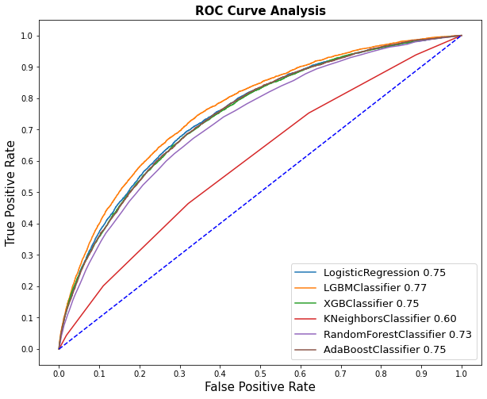

```python
fig = plt.figure(figsize=(10,8))

for i in df_model_over.index:
    plt.plot(df_model_over.loc[i]['fpr'],
             df_model_over.loc[i]['tpr'],
             label=df_model_over.loc[i]['model']+ f" {df_model_over.loc[i]['roc auc score']:.2f}"
             )

plt.plot([0,1], [0,1], color='blue', linestyle='--')

plt.xticks(np.arange(0.0, 1.1, step=0.1))
plt.xlabel("False Positive Rate", fontsize=15)

plt.yticks(np.arange(0.0, 1.1, step=0.1))
plt.ylabel("True Positive Rate", fontsize=15)

plt.title('ROC Curve Analysis', fontweight='bold', fontsize=15)
plt.legend(prop={'size':13}, loc='lower right')

plt.show()
```

## Best models

### Optimization

Optimisation du modèle d'un point de vue métier (fonction coût métier)

On cherche à optimiser le modèle, donc trouver les meilleurs paramètres avec lesquels le modèle est le plus performant.

#### Fonction coût métier

La fonction coût est une estimation du gain financier ou de perte financière pour l’entreprise. Il s’agit d’une problématique métier et l’objectif est de minimiser :

- Le nombre de clients ayant des situations sans risque de défaut de paiement dont les demandes de crédits sont refusées par erreur (l’erreur de type I ou les faux positifs) ;
- Le nombre de crédits accordés par erreur aux clients ayant des risques élevés de défaut de paiement (l’erreur de type II ou les faux négatifs).

Pour atteindre cet objectif, il faut :

- Maximiser le rappel et la précision ;
- Minimiser le taux de faux positifs (FPR) et le taux de faux négatifs (FNR).

La bibliothèque hyperopt a un but similaire à gridsearch, mais au lieu de faire une recherche exhaustive de l’espace de paramètre, il évalue quelques points de données bien choisis, puis extrapole la solution optimale basée sur la modélisation. En pratique, cela signifie qu’il faut souvent beaucoup moins d’itérations pour trouver une bonne solution.

```python
poids = 10 #importance de fn par rapport à fp

def custom_score(y_true, y_pred) :

    '''fonction qui pénalise le faux positive (fp) et le faux négatif (fn)'''

    tp, tn, fp, fn = confusion_matrix(y_true, y_pred).ravel()

    fscore = poids*fn +fp

    return fscore
```

## LGBMClassifier

```python
from sklearn.model_selection import cross_val_predict
#Parameter space
space = {
    'class_weight': hp.choice('class_weight', [None, 'balanced']),
    'boosting_type': hp.choice('boosting_type',['gbdt','dart','goss']),
    'num_leaves': hp.quniform('num_leaves', 30, 150, 1),
    'learning_rate': hp.loguniform('learning_rate', np.log(0.01), np.log(0.2)),
    'subsample_for_bin': hp.quniform('subsample_for_bin', 20000, 300000, 20000),
    'feature_fraction': hp.uniform('feature_fraction', 0.5, 1),
    'bagging_fraction': hp.uniform('bagging_fraction', 0.5, 1), #alias "subsample"
    'min_data_in_leaf': hp.qloguniform('min_data_in_leaf', 0, 6, 1),
    'lambda_l1': hp.choice('lambda_l1', [0, hp.loguniform('lambda_l1_positive', -16, 2)]),
    'lambda_l2': hp.choice('lambda_l2', [0, hp.loguniform('lambda_l2_positive', -16, 2)]),
    'verbose': -1,
    'subsample': None, #overridden by bagging_fraction
    'reg_alpha': None, #overridden by lambda_l1
    'reg_lambda': None, #overridden by lambda_l2
    'min_sum_hessian_in_leaf': None, #overrides min_child_weight
    'min_child_samples': None, #overridden by min_data_in_leaf
    'colsample_bytree': None, #overridden by feature_fraction
    'min_child_weight': hp.loguniform('min_child_weight', -16, 5), #also aliases to min_sum_hessian
}


def objective(params, eval_metric='custom_score'):
    #objective function to be minimized.
    #Hyperopt will seek to minimize the loss returned by this function.

    params = {
        'class_weight':params['class_weight'],
        'boosting_type':params['boosting_type'],
        'num_leaves': int(params['num_leaves']),
        'learning_rate': params['learning_rate'],
        'subsample_for_bin': int(params['subsample_for_bin']),
        'feature_fraction': params['feature_fraction'],
        'bagging_fraction': params['feature_fraction'],
        'min_data_in_leaf': int(params['min_data_in_leaf'])
        }


    model= LGBMClassifier(**params)
    cv = StratifiedKFold(5)
    y_pred = cross_val_predict(model, X_train_over_sm, y_train_over_sm, method='predict', cv=cv)
    score = custom_score(y_train_over_sm, y_pred)

    loss = 1 - score
    return {'loss': loss, 'params': params, 'status': STATUS_OK}
```

```python
best = fmin(fn=objective, space=space, max_evals=10, algo=tpe.suggest)
```

```python
print("Hyperopt estimated optimum {}".format(best))
```

```
Hyperopt estimated optimum {'bagging_fraction': 0.9354953794273403, 'boosting_type': 1, 'class_weight': 1, 'feature_fraction': 0.93024312875431, 'lambda_l1': 0, 'lambda_l2': 1, 'lambda_l2_positive': 0.0012127982318298192, 'learning_rate': 0.18505249030026003, 'min_child_weight': 10.32070386760009, '…
```

```python
lgbm = LGBMClassifier( #Fit a new model based on the best parameters
    num_leaves= int(best['num_leaves']),
    learning_rate= best['learning_rate'],
    subsample_for_bin= int(best['subsample_for_bin']),
    feature_fraction= best['feature_fraction'],
    bagging_fraction= best['feature_fraction'],
    min_data_in_leaf= int(best['min_data_in_leaf']),)

lgbm.fit(X_train_over_sm, y_train_over_sm)
```

```
LGBMClassifier(bagging_fraction=0.93024312875431,
               feature_fraction=0.93024312875431,
               learning_rate=0.18505249030026003, min_data_in_leaf=25,
               num_leaves=99, subsample_for_bin=240000)
```

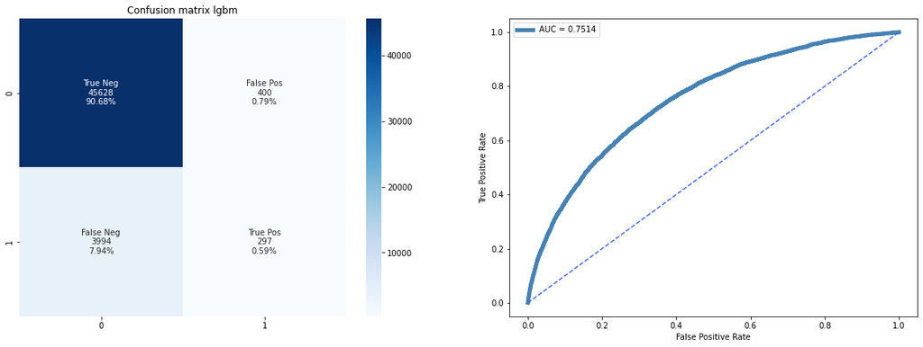

```python
y_pred_over = lgbm.predict(X_test)
y_pred_proba_over = lgbm.predict_proba(X_test)[:,1]

fig = plt.figure(figsize=(20,15))

plt.subplot(221)
# Compute confusion matrix
cnf_matrix = confusion_matrix(y_test, y_pred_over)
group_names = ['True Neg', 'False Pos', 'False Neg', 'True Pos']
group_counts = ["{0:0.0f}".format(value) for value in cnf_matrix.flatten()]
group_percentages = ["{0:.2%}".format(value) for value in cnf_matrix.flatten()/np.sum(cnf_matrix)]

labels = [f"{v1}\n{v2}\n{v3}" for v1, v2, v3 in zip(group_names,group_counts,group_percentages)]
labels = np.asarray(labels).reshape(2,2)
sns.heatmap(cnf_matrix, annot=labels, fmt="", cmap='Blues')

plt.title(f'Confusion matrix lgbm')


plt.subplot(222)
fpr,tpr,_ = roc_curve(y_test, y_pred_proba_over)
plt.plot(fpr, tpr, color='steelblue', linewidth=5, label='AUC = %0.4f' %roc_auc_score(y_test, y_pred_proba_over))
plt.plot([0, 1], [0, 1], color='royalblue', linestyle='--')
plt.xlabel('False Positive Rate')
plt.ylabel('True Positive Rate')
plt.legend()

plt.show()
```

```python
lgbm.score(X_test,y_test)

predictions = lgbm.predict(X_test)

# print classification report
print(classification_report(y_test, predictions))
```

```
              precision    recall  f1-score   support

         0.0       0.92      0.99      0.95     46028
         1.0       0.43      0.07      0.12      4291

    accuracy                           0.91     50319
   macro avg       0.67      0.53      0.54     50319
weighted avg       0.88      0.91      0.88     50319
```

# Feature Importance

Librairie SHAP pour calculer la feature importance globale afin de connaitre d'une manière générale les principales features qui contribuent à l'élaboration du modèle.

features importance des prédictions faites par le modèle sur xtest

```python
import shap

# DF, based on which importance is checked
X_importance = X_test

# Explain model predictions using shap library:
explainer = shap.TreeExplainer(lgbm)
shap_values = explainer.shap_values(X_importance)
```

```
LightGBM binary classifier with TreeExplainer shap values output has changed to a list of ndarray
```

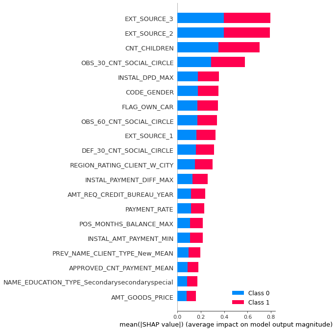

```python
# Plot summary_plot
shap.summary_plot(shap_values, X_importance)
```

[output not shown]

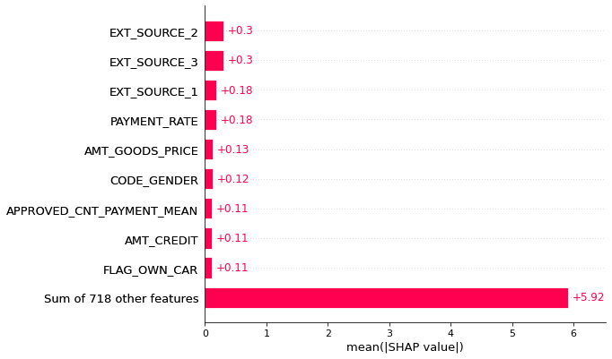

```python
# compute SHAP values
explainer = shap.Explainer(lgbm, X_train)
shap_values = explainer(X_train, check_additivity=False)
shap.plots.bar(shap_values)
```

```python
import pickle

pickle.dump(lgbm, open("LGBMClassifier.pkl", "wb"))
```

```python
#X_train_over_sm.to_csv("train.csv")
#X_test.to_csv("test.csv")
#y.to_csv('TARGET.csv')
```

```python
sample_export = X_train.reset_index()
```

```python
# échantillon pour l'API
sample_export = sample_export.sample(frac=0.35, random_state=8)

# save datas to csv
sample_export.to_csv('sample_preproc.csv')
```

```python
customer_sample = application_train[application_train.SK_ID_CURR.isin(sample_export.SK_ID_CURR.values.tolist())]
```

```python
customer_sample = customer_sample[["SK_ID_CURR","NAME_FAMILY_STATUS","NAME_EDUCATION_TYPE","NAME_INCOME_TYPE","NAME_CONTRACT_TYPE","CODE_GENDER","AMT_INCOME_TOTAL","OCCUPATION_TYPE","DAYS_BIRTH","DAYS_EMPLOYED"]]
```

```python
customer_sample = customer_sample.rename(columns = lambda x:re.sub('[^A-Za-z0-9_]+ ', '', x))
```

```python
# save to csv
customer_sample.to_csv('customer_sample.csv')
```

```python
# %%flake8

# create an explainer with model and datas preprocessed
explainer = shap.Explainer(lgbm, X_train)
```

```python
pickle.dump(explainer, open('explainer.pkl', 'wb'))
```

```python
# export shap_values
shap_values_export = explainer(sample_export, check_additivity=False)

pickle.dump(shap_values_export, open('shap_values.pkl', 'wb'))
```

```
100%|===================| 41064/41094 [06:04<00:00]
```

## Conclusion

LightGbm ressort comme étant le plus rapide, le plus performant sur la métrique classique de l'AUC

```python
customerid = 141754
```

```python
def load_prediction(sample, customerid, clf):
    X=sample.iloc[:, :-1]
    score = clf.predict_proba(X[X.SK_ID_CURR == int(customerid)])[:,1]
    return score

prediction = load_prediction(sample_export, customerid, lgbm)
```

```python
prediction
```

```
array([0.72480959])
```

```python
pickle.dump(sample_export, open('sample_export.pkl', 'wb'))
```

```python
sample
```

|  | SK_ID_CURR | CODE_GENDER | FLAG_OWN_CAR | FLAG_OWN_REALTY | CNT_CHILDREN | AMT_INCOME_TOTAL | AMT_CREDIT | AMT_ANNUITY | AMT_GOODS_PRICE | REGION_POPULATION_RELATIVE | DAYS_BIRTH | DAYS_EMPLOYED | OWN_CAR_AGE | CNT_FAM_MEMBERS | REGION_RATING_CLIENT | REGION_RATING_CLIENT_W_CITY | EXT_SOURCE_1 | EXT_SOURCE_2 | EXT_SOURCE_3 | APARTMENTS_MODE | BASEMENTAREA_MODE | YEARS_BEGINEXPLUATATION_MODE | YEARS_BUILD_MODE | COMMONAREA_MODE | ELEVATORS_MODE | ENTRANCES_MODE | FLOORSMAX_MODE | FLOORSMIN_MODE | LANDAREA_MODE | … |
| --- | --- | --- | --- | --- | --- | --- | --- | --- | --- | --- | --- | --- | --- | --- | --- | --- | --- | --- | --- | --- | --- | --- | --- | --- | --- | --- | --- | --- | --- | --- |
| 24550 | 146580 | 1.0 | 1.0 | 0.0 | 0.00277 | -0.000227 | -0.011236 | -0.007732 | -0.011236 | 1.873337 | 1.438057 | 1.000055 | 0.000725 | -0.047091 | -0.25 | -0.25 | 0.715261 | 0.699017 | 0.926777 | 0.0840 | 0.0747 | 0.9816 | 0.7648 | 0.0190 | 0.0000 | 0.1379 | 0.1667 | 0.2083 | 0.0460 | … |
| 40153 | 163379 | 1.0 | 1.0 | 0.0 | 0.00000 | -0.000227 | -0.011236 | -0.007733 | -0.011236 | 6.798825 | 1.438050 | 1.000049 | 0.001328 | -0.049861 | -0.25 | -0.25 | 0.532816 | 0.775643 | 0.814609 | 0.0840 | 0.0747 | 0.9816 | 0.7648 | 0.0190 | 0.0000 | 0.1379 | 0.1667 | 0.2083 | 0.0460 | … |
| 21916 | 398930 | 0.0 | 1.0 | 1.0 | 0.00000 | -0.000227 | -0.011236 | -0.007732 | -0.011236 | 2.148799 | 1.438078 | 1.000053 | 0.001087 | -0.049861 | -0.25 | -0.25 | 0.559298 | 0.664974 | 0.431927 | 0.0840 | 0.0747 | 0.9816 | 0.7648 | 0.0190 | 0.0000 | 0.1379 | 0.1667 | 0.2083 | 0.0460 | … |
| 2176 | 158010 | 0.0 | 1.0 | 0.0 | 0.00554 | -0.000227 | -0.011236 | -0.007733 | -0.011236 | 1.753848 | 1.438066 | 1.000048 | 0.000121 | -0.044321 | -0.25 | -0.25 | 0.532816 | 0.828398 | 0.998607 | 0.0840 | 0.0747 | 0.9816 | 0.7648 | 0.0190 | 0.0000 | 0.1379 | 0.1667 | 0.2083 | 0.0460 | … |
| 61582 | 427354 | 1.0 | 0.0 | 0.0 | 0.00554 | -0.000227 | -0.011236 | -0.007733 | -0.011236 | 5.826506 | 1.438072 | 1.000045 | 0.001087 | -0.044321 | -0.25 | -0.25 | 0.304011 | 0.898067 | 0.772724 | 0.0840 | 0.0747 | 0.9816 | 0.7648 | 0.0190 | 0.0000 | 0.1379 | 0.1667 | 0.2083 | 0.0460 | … |
| ... | ... | ... | ... | ... | ... | ... | ... | ... | ... | ... | ... | ... | ... | ... | ... | ... | ... | ... | ... | ... | ... | ... | ... | ... | ... | ... | ... | ... | ... | … |
| 46765 | 143606 | 0.0 | 1.0 | 0.0 | 0.00277 | -0.000227 | -0.011236 | -0.007733 | -0.011236 | 0.573245 | 1.438055 | 1.000055 | 0.000725 | -0.047091 | -0.50 | -0.50 | 0.532816 | 0.875755 | 0.727197 | 0.1250 | 0.0700 | 0.9955 | 0.9412 | 0.0417 | 0.1208 | 0.1034 | 0.3750 | 0.2083 | 0.0146 | … |
| 86966 | 127064 | 1.0 | 0.0 | 1.0 | 0.00277 | -0.000227 | -0.011236 | -0.007732 | -0.011236 | 3.369940 | 1.438062 | 1.000048 | 0.001087 | -0.049861 | 0.00 | -0.25 | 0.532816 | 0.805924 | 0.804293 | 0.0630 | 0.0000 | 0.9901 | 0.8693 | 0.0123 | 0.0000 | 0.1034 | 0.1667 | 0.2083 | 0.0111 | … |
| 23327 | 198173 | 0.0 | 1.0 | 1.0 | 0.00000 | -0.000227 | -0.011236 | -0.007733 | -0.011236 | 3.404686 | 1.438077 | 1.000052 | 0.001208 | -0.052632 | 0.00 | 0.00 | 0.246443 | 0.504756 | 0.885312 | 0.2258 | 0.1764 | 0.9851 | 0.8040 | 0.1239 | 0.2417 | 0.2069 | 0.3333 | 0.3750 | 0.1086 | … |
| 59990 | 263774 | 1.0 | 0.0 | 0.0 | 0.00000 | -0.000227 | -0.011236 | -0.007732 | -0.011236 | 4.290911 | 1.438038 | 1.000042 | 0.001087 | -0.052632 | -0.25 | -0.25 | 0.853043 | 0.612743 | 0.369037 | 0.0756 | 0.0505 | 0.9846 | 0.7975 | 0.0143 | 0.0806 | 0.0690 | 0.3333 | 0.3750 | 0.0460 | … |
| 109453 | 316566 | 1.0 | 1.0 | 0.0 | 0.00554 | -0.000227 | -0.011236 | -0.007733 | -0.011236 | 2.148799 | 1.438072 | 1.000051 | 0.002053 | -0.044321 | -0.25 | -0.25 | 0.415464 | 0.908067 | 0.698412 | 0.1061 | 0.1159 | 0.9777 | 0.7060 | 0.0395 | 0.0000 | 0.2069 | 0.1667 | 0.0417 | 0.0878 | … |

41094 rows × 728 columns